# The data used is this project is 100% real and is scraped autonomously from different tech publisher websites starting from 1/July/2026.

```python
df_articles.columns
```

```
Index(['article_id', 'title', 'summary', 'article_url', 'source_name',
       'country', 'language', 'category_name', 'published_at',
       'published_date', 'published_year', 'published_month', 'month_name',
       'quarter', 'week_number', 'weekday', 'word_count', 'reading_time',
       'scraped_at'],
      dtype='object')
```

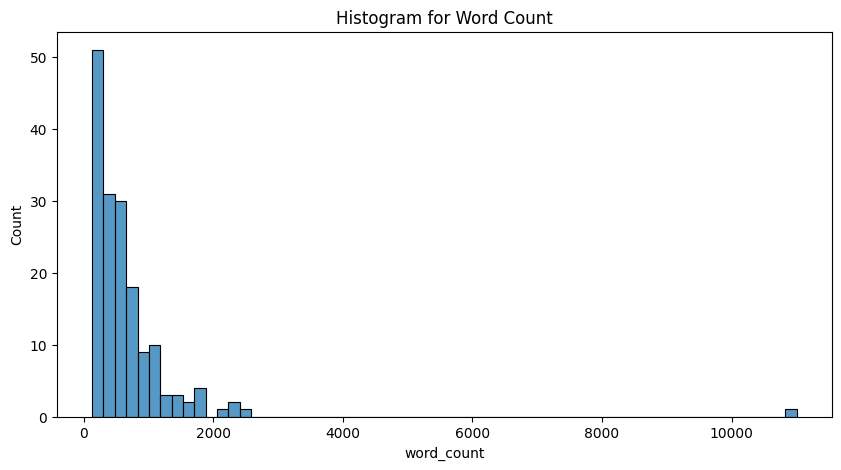

```python
plt.figure(figsize=(10,5))
plt.title("Histogram for Word Count")
sns.histplot(df_articles["word_count"])
plt.show()
```

```python
df_articles.columns
```

[output not shown]

```python
df_articles["word_count"].skew()
```

```
np.float64(8.541900268872997)
```

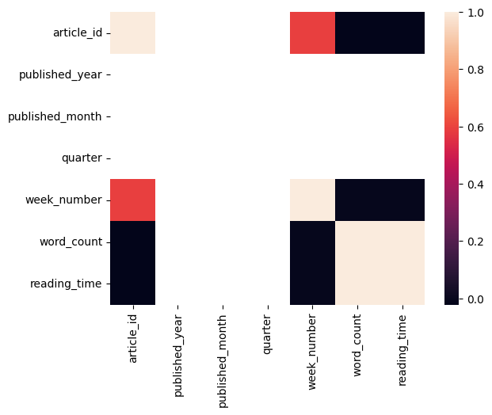

```python
df_corr = df_articles.corr(numeric_only=True)

sns.heatmap(df_corr)
```

- Word count and Reading time are positively correlated which means when one increases other also increases.

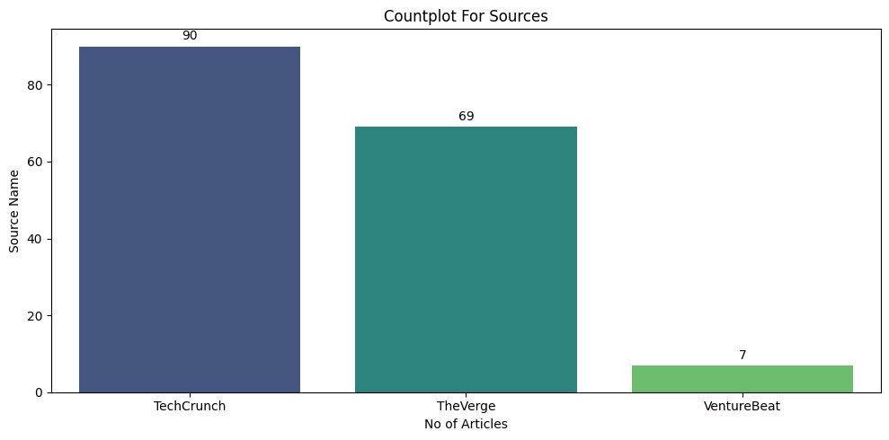

```python
plt.figure(figsize=(10,5))

ax = sns.countplot(
    data = df_articles,
    x='source_name',
    hue='source_name',
    palette='viridis'
)

plt.title("Countplot For Sources")
plt.xlabel("No of Articles")
plt.ylabel("Source Name")

for container in ax.containers:
  ax.bar_label(container, fmt="%d", padding=3, fontsize=10)

plt.tight_layout()
plt.show()
```

```python
df_articles.groupby('category_name')['article_id'].count().reset_index().sort_values(by=['article_id'], ascending=False)
```

|  | category_name | article_id |
| --- | --- | --- |
| 1 | AI | 38 |
| 0 |  | 20 |
| 26 | Tech | 19 |
| 9 | Gadgets | 14 |
| 24 | Startups | 8 |
| 21 | Security | 7 |
| 28 | Transportation | 7 |
| 2 | Apps | 6 |
| 6 | Entertainment | 5 |
| 16 | Policy | 5 |
| 10 | Gaming | 5 |
| 5 | Column | 3 |
| 22 | Social | 3 |
| 15 | Podcasts | 3 |
| 27 | Technology | 3 |
| 14 | Orchestration | 2 |
| 29 | Venture | 2 |
| 25 | Streaming | 2 |
| 11 | Hardware | 2 |
| 12 | Media & Entertainment | 2 |
| 3 | Artificial Intelligence | 1 |
| 4 | Biotech & Health | 1 |
| 13 | News | 1 |
| 8 | Fundraising | 1 |
| 7 | Fintech | 1 |
| 17 | Report | 1 |
| 20 | Science | 1 |
| 19 | Robotics | 1 |
| 18 | Reviews | 1 |
| 23 | Space | 1 |

### Analysis:

Q1. How are the article lengths distributed across the entire dataset ?

```python
bins = [0,200, 400, 600, 1000, 2000 , float('inf')]
labels = ['Till 200', 'till 400', 'Till 600', 'till 1000', 'till 2000', 'Beyond 2000' ]

df_articles['binned_words_buckets'] = pd.cut(
    df_articles['word_count'],
    bins=bins,
    labels=labels
)
```

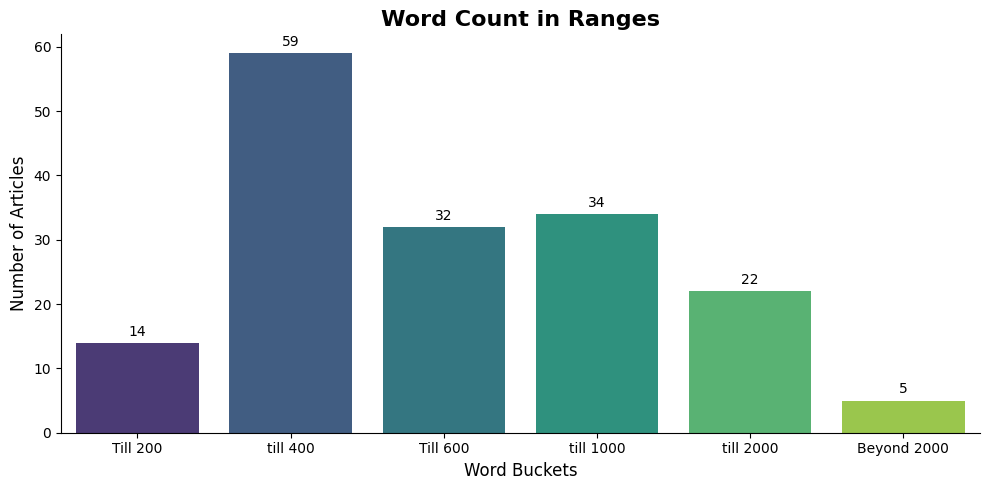

```python
plt.figure(figsize=(10,5))
ax = sns.countplot(
    data=df_articles,
    x="binned_words_buckets",
    palette="viridis"
)

plt.title("Word Count in Ranges", fontsize=16, weight="bold")
plt.xlabel("Word Buckets", fontsize=12)
plt.ylabel("Number of Articles", fontsize=12)

# Add values on top of bars
for container in ax.containers:
    ax.bar_label(container, fmt="%d", fontsize=10, padding=3)

sns.despine()
plt.tight_layout()
plt.show()
```

Q2. How is Reading Time distributed among articles ?

```python
df_articles['reading_time'].unique()

bins=[0,10,20,float('inf')]
labels=['Upto 5', 'Upto 20', 'Beyond 20']

df_articles['binned_reading_time'] = pd.cut(
    df_articles['reading_time'],
    bins=bins,
    labels=labels
)
```

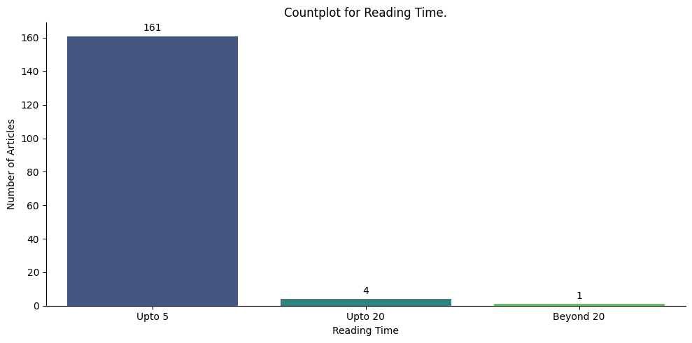

```python
plt.figure(figsize=(10,5))

ax = sns.countplot(
    data=df_articles,
    x='binned_reading_time',
    hue='binned_reading_time',
    palette='viridis'
)

for container in ax.containers:
  ax.bar_label(container, fmt="%d", fontsize=10, padding=3)

plt.title("Countplot for Reading Time.")
plt.xlabel("Reading Time")
plt.ylabel("Number of Articles")

sns.despine()
plt.tight_layout()
plt.show()
```

Q3. Are article Lengths normally distributed or heavily skewed.

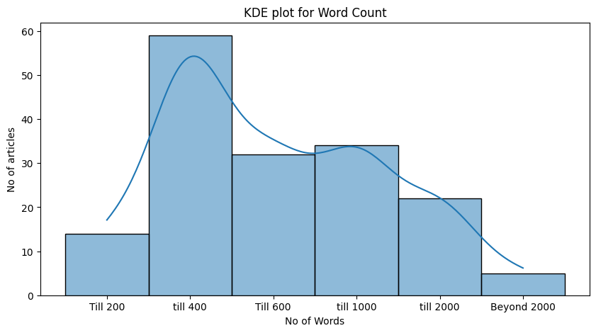

```python
plt.figure(figsize=(10,5))

sns.histplot(
    data=df_articles,
    x='binned_words_buckets',
    palette='viridis',
    kde=True
)

plt.title("KDE plot for Word Count")
plt.xlabel("No of Words")
plt.ylabel("No of articles")
plt.show()
```

- The articles are not distributed normally. The distribution is right skewed.

Q4. Do outliers exist in article length and reading time ?

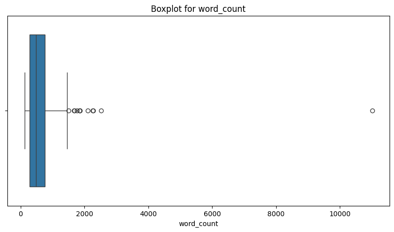

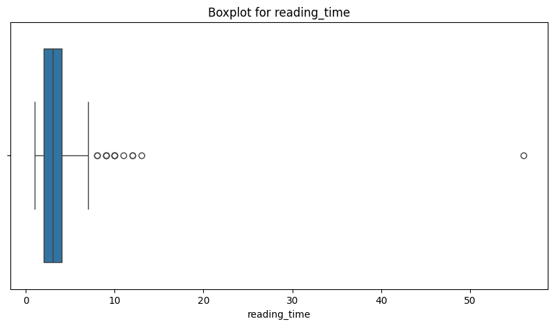

```python
cols = ['word_count', 'reading_time']

for col in cols:

  plt.figure(figsize=(10,5))

  plt.title(f"Boxplot for {col}")

  sns.boxplot(
      data=df_articles,
      x=col
  )

  plt.show()
```

- Yes there exist few outliers in the dataset basing upon the word count.

### Author Related Analytics:

```python
df_authors.head()
```

|  | article_id | title | source_name | author_id | display_name |
| --- | --- | --- | --- | --- | --- |
| 0 | 180113 | EU threatens Meta with fines over addictive fe... | TechCrunch | 28 | Aisha Malik |
| 1 | 45 | Google Photos adds a new AI ‘Video Remix’ tool | TechCrunch | 28 | Aisha Malik |
| 2 | 180110 | Dumb Co dared me to trade my iPhone for a hack... | TechCrunch | 27 | Amanda Silberling |
| 3 | 42 | ‘Slow-cial’ app Roost forces you to slow down ... | TechCrunch | 27 | Amanda Silberling |
| 4 | 39 | With EU backing, QuantumDiamonds aims to speed... | TechCrunch | 7 | Anna Heim |

```python
df_authors.info()
```

```
<class 'pandas.core.frame.DataFrame'>
RangeIndex: 148 entries, 0 to 147
Data columns (total 5 columns):
 #   Column        Non-Null Count  Dtype
---  ------        --------------  -----
 0   article_id    148 non-null    int64
 1   title         148 non-null    object
 2   source_name   148 non-null    object
 3   author_id     148 non-null    int64
 4   display_name  148 non-null    object
dtypes: int64(2), object(3)
memory usage: 5.9+ KB
```

Q7. Which authors specialize in a single publisher, and which contribute across multiple publishers?

```python
df_authors[["source_name","display_name"]].head(20)

df_authors.groupby('display_name')['source_name'].nunique().sort_values(ascending=False).reset_index(name="No_of_sources")
```

|  | display_name | No_of_sources |
| --- | --- | --- |
| 0 | Aisha Malik | 1 |
| 1 | Amanda Silberling | 1 |
| 2 | Andrew J. Hawkins | 1 |
| 3 | Andrew Liszewski | 1 |
| 4 | Andrew Webster | 1 |
| 5 | Anna Heim | 1 |
| 6 | Antonio G. Di Benedetto | 1 |
| 7 | Brad Bourque | 1 |
| 8 | Cameron Faulkner | 1 |
| 9 | Charles Pulliam-Moore | 1 |
| 10 | Connie Loizos | 1 |
| 11 | David Imel | 1 |
| 12 | David Pierce | 1 |
| 13 | Dominic Preston | 1 |
| 14 | Emma Roth | 1 |
| 15 | Gaby Del Valle | 1 |
| 16 | Hayden Field | 1 |
| 17 | Isabelle Johannessen | 1 |
| 18 | Ivan Mehta | 1 |
| 19 | Jagmeet Singh | 1 |
| 20 | Jay Peters | 1 |
| 21 | Jennifer Pattison Tuohy | 1 |
| 22 | John Higgins | 1 |
| 23 | Julie Bort | 1 |
| 24 | Kate Park | 1 |
| 25 | Kirsten Korosec | 1 |
| 26 | Lauren Forristal | 1 |
| 27 | Lucas Ropek | 1 |
| 28 | Maggie Nye | 1 |
| 29 | Marina Temkin | 1 |
| 30 | Michael Nuñez | 1 |
| 31 | Nilay Patel | 1 |
| 32 | Ram Iyer | 1 |
| 33 | Rebecca Bellan | 1 |
| 34 | Russell Brandom | 1 |
| 35 | Sarah Perez | 1 |
| 36 | Sean Hollister | 1 |
| 37 | Sean O'Kane | 1 |
| 38 | Sheena Vasani | 1 |
| 39 | Stevie Bonifield | 1 |
| 40 | TC Sottek | 1 |
| 41 | Terrence O'Brien | 1 |
| 42 | Theresa Loconsolo | 1 |
| 43 | Thomas Ricker | 1 |
| 44 | Tim Fernholz | 1 |
| 45 | VB Staff | 1 |
| 46 | Victoria Song | 1 |
| 47 | Zack Whittaker | 1 |

- As of now each of the authors are associated with a single Publisher.

Q8. What is the distribution of article contributions per author ?

```python
df_authors.groupby('display_name')['article_id'].count().reset_index(name='article_count').sort_values(by='article_count', ascending=False)
```

|  | display_name | article_count |
| --- | --- | --- |
| 35 | Sarah Perez | 10 |
| 20 | Jay Peters | 10 |
| 41 | Terrence O'Brien | 9 |
| 14 | Emma Roth | 6 |
| 27 | Lucas Ropek | 6 |
| 25 | Kirsten Korosec | 5 |
| 47 | Zack Whittaker | 5 |
| 7 | Brad Bourque | 4 |
| 16 | Hayden Field | 4 |
| 19 | Jagmeet Singh | 4 |
| 39 | Stevie Bonifield | 4 |
| 30 | Michael Nuñez | 4 |
| 38 | Sheena Vasani | 4 |
| 44 | Tim Fernholz | 4 |
| 33 | Rebecca Bellan | 4 |
| 8 | Cameron Faulkner | 3 |
| 45 | VB Staff | 3 |
| 43 | Thomas Ricker | 3 |
| 26 | Lauren Forristal | 3 |
| 34 | Russell Brandom | 3 |
| 12 | David Pierce | 3 |
| 29 | Marina Temkin | 3 |
| 23 | Julie Bort | 3 |
| 18 | Ivan Mehta | 3 |
| 13 | Dominic Preston | 3 |
| 1 | Amanda Silberling | 2 |
| 0 | Aisha Malik | 2 |
| 2 | Andrew J. Hawkins | 2 |
| 5 | Anna Heim | 2 |
| 15 | Gaby Del Valle | 2 |
| 10 | Connie Loizos | 2 |
| 9 | Charles Pulliam-Moore | 2 |
| 46 | Victoria Song | 2 |
| 21 | Jennifer Pattison Tuohy | 2 |
| 36 | Sean Hollister | 2 |
| 42 | Theresa Loconsolo | 2 |
| 24 | Kate Park | 2 |
| 3 | Andrew Liszewski | 1 |
| 4 | Andrew Webster | 1 |
| 6 | Antonio G. Di Benedetto | 1 |
| 11 | David Imel | 1 |
| 28 | Maggie Nye | 1 |
| 17 | Isabelle Johannessen | 1 |
| 22 | John Higgins | 1 |
| 31 | Nilay Patel | 1 |
| 32 | Ram Iyer | 1 |
| 37 | Sean O'Kane | 1 |
| 40 | TC Sottek | 1 |

Q9. Which Publishers rely on a small group of authors versus a diverse author base ?

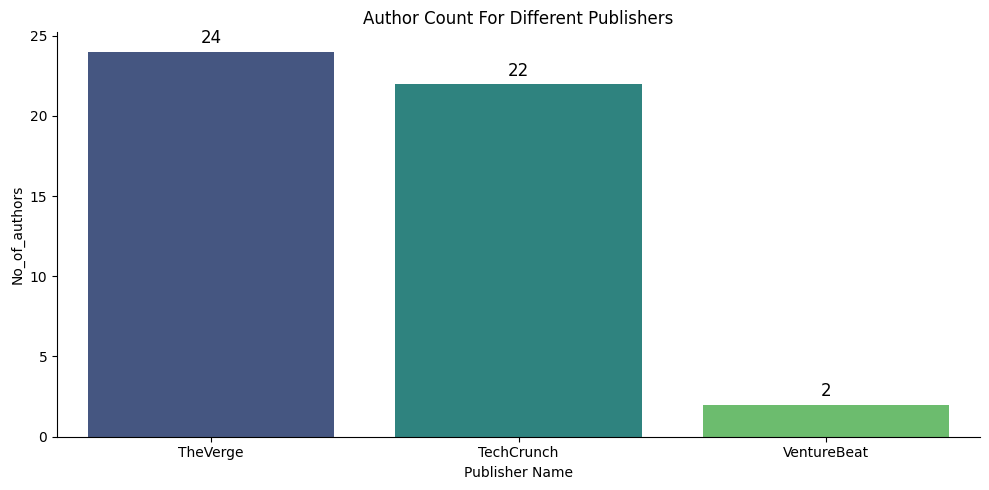

```python
publisher_authors = df_authors.groupby('source_name')['author_id'].nunique().sort_values(ascending=False).reset_index(name="No_of_authors")

plt.figure(figsize=(10,5))

ax = sns.barplot(
    data=publisher_authors,
    x="source_name",
    y="No_of_authors",
    palette='viridis'
)

plt.title("Author Count For Different Publishers")
plt.xlabel("Publisher Name")
plt.ylabel("No_of_authors")

for container in ax.containers:
  ax.bar_label(container, fmt="%d", fontsize=12, padding=3)

sns.despine()
plt.tight_layout()
plt.show()
```

Q10. Is article production evenly distributed, or some authors dominate in production ?

```python
df_authors.shape
```

```
(148, 5)
```

```python
authors_and_their_total_articles = df_authors.groupby('display_name')['article_id'].count().sort_values(ascending=False).reset_index(name="no_of_articles")
articles_buckets = authors_and_their_total_articles.groupby('no_of_articles')['display_name'].count().sort_values(ascending=False).reset_index(name="no_of_authors")
articles_buckets
```

|  | no_of_articles | no_of_authors |
| --- | --- | --- |
| 0 | 2 | 12 |
| 1 | 1 | 11 |
| 2 | 3 | 10 |
| 3 | 4 | 8 |
| 4 | 5 | 2 |
| 5 | 6 | 2 |
| 6 | 10 | 2 |
| 7 | 9 | 1 |

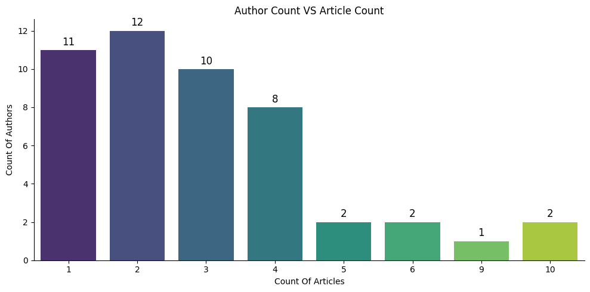

```python
plt.figure(figsize=(10,5))

ax = sns.barplot(
    data=articles_buckets,
    x="no_of_articles",
    y="no_of_authors",
    palette="viridis"
)

plt.title("Author Count VS Article Count")
plt.xlabel("Count Of Articles")
plt.ylabel("Count Of Authors")

for container in ax.containers:
  ax.bar_label(container, fmt="%d", fontsize=12, padding=3)

sns.despine()
plt.tight_layout()
plt.show()
```

Q11. Can Authors be grouped into different writing profiles ?

```python
df_articles['content_type'] = df_articles['word_count'].apply(
    lambda x: "short_form" if x<500 else "long_form"
)
```

```python
articles_with_types = df_articles[['article_id', "content_type"]]

authors_with_articles = df_authors[['author_id','display_name','article_id']]
```

```python
merged_df = articles_with_types.merge(authors_with_articles, on='article_id', how='inner')

content_type_distribution = merged_df.groupby('content_type')['display_name'].nunique().sort_values(ascending=False).reset_index(name='no_of_authors')
```

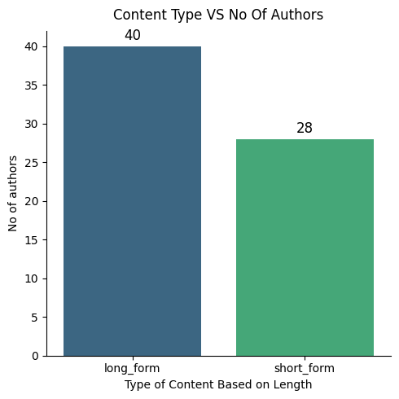

```python
plt.figure(figsize=(5,5))

ax = sns.barplot(
    data=content_type_distribution,
    x='content_type',
    y='no_of_authors',
    hue="content_type",
    palette='viridis'
)

plt.title("Content Type VS No Of Authors", pad=10)
plt.xlabel("Type of Content Based on Length")
plt.ylabel("No of authors")

for container in ax.containers:
  ax.bar_label(container, fmt="%d", fontsize=12, padding=3)

sns.despine()
plt.tight_layout()
plt.show()
```

### Tags related Analysis:

```python
df_tags.head()
```

|  | article_id | title | source_name | tag_name | published_at |
| --- | --- | --- | --- | --- | --- |
| 0 | 5 | Hot French startup ZML releases free product t... | TechCrunch | AI | 2026-07-08 01:00:00 |
| 1 | 5 | Hot French startup ZML releases free product t... | TechCrunch | Startups | 2026-07-08 01:00:00 |
| 2 | 5 | Hot French startup ZML releases free product t... | TechCrunch | AI inference | 2026-07-08 01:00:00 |
| 3 | 5 | Hot French startup ZML releases free product t... | TechCrunch | Europe | 2026-07-08 01:00:00 |
| 4 | 5 | Hot French startup ZML releases free product t... | TechCrunch | Exclusive | 2026-07-08 01:00:00 |

Q12. How are tags distributed across the dataset ?

```python
tags_distribution = df_tags.groupby('tag_name')['article_id'].count().sort_values(ascending=False).reset_index(name="frequency")
tags_distribution
```

|  | tag_name | frequency |
| --- | --- | --- |
| 0 | AI | 62 |
| 1 | Tech | 44 |
| 2 | News | 32 |
| 3 | Gadgets | 29 |
| 4 | Apps | 22 |
| ... | ... | ... |
| 292 | publisher | 1 |
| 293 | quantum computing | 1 |
| 294 | quantum sensing | 1 |
| 295 | quantumdiamonds | 1 |
| 296 | radical ventures | 1 |

297 rows × 2 columns

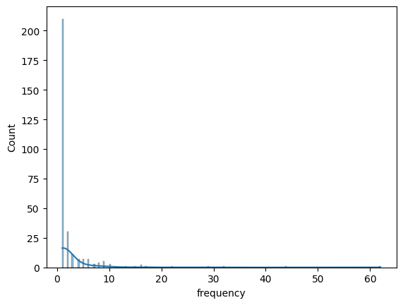

```python
sns.histplot(
  data=tags_distribution,
  x='frequency',
  kde=True
)
```

- The Tags distribution is heavily skewed on the right side.
- Further analysis will be done after we acquire reasonable amount of data.

# Overall Findings

Overall, the current dataset confirms that the TechPulse pipeline is functioning correctly and producing meaningful analytical results despite being in the early stages of data collection.

# Recommendations

Based on the analysis performed on the current dataset, the following recommendations are proposed for the TechPulse platform:

- Continue executing the automated ETL pipeline on a scheduled basis to build a larger historical repository of technology news articles.
- Periodically monitor scraper performance and update parsers whenever publisher website structures change.
- Increase the number of supported technology news sources to improve coverage and reduce publisher-specific bias.
- Monitor database growth and perform routine optimization to maintain efficient query performance as the dataset expands.
- Build interactive dashboards using Tableau or Power BI for real-time exploration of publisher activity, technology trends, and article statistics.
- Once a sufficiently large historical dataset has been collected, extend the platform with advanced analytics including sentiment analysis, topic modeling, keyword extraction, trend detection, and predictive analytics.

# Project Status

At this stage, TechPulse has reached a stable operational state.

The complete data engineering pipeline has been successfully implemented, including automated web scraping, data extraction, transformation, loading into a relational database, SQL-based analytical queries, and Python-based exploratory data analysis and visualization.

The primary objective of this phase was to establish a reliable end-to-end analytics platform capable of continuously collecting and organizing technology news from multiple publishers. This objective has been successfully achieved.

The analyses presented in this notebook validate both the integrity of the collected data and the effectiveness of the overall pipeline. The generated insights demonstrate that the platform is capable of supporting meaningful analytical workflows while providing a strong foundation for future enhancements.

# Future Scope

The current dataset represents the initial stage of continuous data collection. Although sufficient for exploratory analysis and validating the functionality of the pipeline, advanced analytical techniques require a significantly larger historical dataset to produce reliable and statistically meaningful results.

For this reason, the TechPulse pipeline will continue operating in its current automated state, periodically collecting new articles and expanding the underlying database without requiring further structural modifications.

Once sufficient historical data has been accumulated, the following enhancements are planned:

- Trend analysis across weeks and months.
- Sentiment analysis of technology news articles.
- Topic modeling to identify emerging technology domains.
- Named Entity Recognition (NER) for organizations, products, and technologies.
- Technology trend forecasting using historical publishing patterns.
- Interactive business intelligence dashboards with real-time updates.
- Machine learning models for article categorization and content recommendation.

This phased development approach ensures that future analyses are based on a sufficiently large and representative dataset, resulting in more accurate, reliable, and actionable insights.

# Conclusion

This project successfully demonstrates the design and implementation of an end-to-end technology news analytics platform. Beginning with automated data collection from multiple news publishers, the project established a complete ETL pipeline, designed a normalized relational database, performed business-oriented SQL analysis, and generated Python-based visualizations to uncover meaningful patterns within the collected data.

The current implementation provides a stable and scalable foundation capable of continuously collecting technology news over time. While the present analysis validates the effectiveness of the platform, future analytical capabilities will become increasingly valuable as additional historical data is accumulated through the automated pipeline.

TechPulse therefore serves not only as a data analytics project but also as a production-ready data engineering platform that can be extended with advanced analytics, Natural Language Processing, and machine learning techniques in future iterations.